# Practical Machine Learning Project

John Plaxton

October 8, 2018

One thing that people regularly do is quantify how much of a particular activity they do, but they rarely quantify how well they do it. The goal of this project is to use data from accelerometers on the belt, forearm, arm, and dumbell of 6 participants to predict the manner in which they did the exercise. This is the “classe” variable in the training set. Three machine learning models are evaluated for out of sample accuracy to select one to use to predict the exercise (classe) of 20 test cases.

```r
# Input data sets for model building and prediction
set.seed(123)
TrainDataset <- read.csv("pml-training.csv")
TestDataset <- read.csv("pml-testing.csv")
```

Train dataset is 19622, 160 observations and columns

Test dataset is 20, 160 observations and columns. This dataset is the 20 test cases that the selected machine learning model will be used on to predict exercise (classe).

## Cleaning Data Sets

The training data set consists of 19622 observations of 160 columns of data. A quick inspection of the training data set shows many columns have NA values (see Appendix for output). Columns with a large number of NAs or blanks are removed from the dataset as they will not provide value as predictors in the machine learning models. Similarly, the first seven columns provide information and timestamps about the test subjects. Again, these columns are removed as they will not be predictors of exercise type.

```r
# Identify columns where more than 90% of entries are NA or blank
indColToRemove <- which(colSums(is.na(TrainDataset) |TrainDataset=="")>0.9*dim(TrainDataset)[1])
TrainDatasetClean <- TrainDataset[,-indColToRemove]

# Remove first seven columns
TrainDatasetClean <- TrainDatasetClean[,-c(1:7)]
dim(TrainDatasetClean)
```

```
## [1] 19622    53
```

After cleaning, 53 columns of data remains in the training dataset

```r
# Applying the same data cleaning procedure to the test set
indColToRemove <- which(colSums(is.na(TestDataset) |TestDataset=="")>0.9*dim(TestDataset)[1])
TestDatasetClean <- TestDataset[,-indColToRemove]
TestDatasetClean <- TestDatasetClean[,-c(1:7)]
dim(TestDatasetClean)
```

```
## [1] 20 53
```

Similarly, after cleaning, 53 columns of data remain in the test dataset.

Preparing the training dataset for machine learning study…

```r
#Partitioning the TrainDatasetClean for model creation
inTrain <- createDataPartition(y=TrainDatasetClean$classe, p=0.75, list=FALSE)
training <- TrainDatasetClean[inTrain,]
testing <- TrainDatasetClean[-inTrain,]
```

## Machine Learning Model Selection

In this section, three machine learning models will be considered:

- classification tree
- random forest
- gradient boosting method

In order to limit overfitting and improve model efficiency, 5-fold cross-validation will be applied.

```r
#configure parallel processing
library(parallel)
library(doParallel)
cluster <- makeCluster(detectCores() - 1) # convention to leave 1 core for OS
registerDoParallel(cluster)

# 5-fold cross-validation specified for all ML models, and enable parallel processing
trControl <- trainControl(method="cv", number=5, allowParallel = TRUE)
```

### Classification Tree

```r
model_CT <- train(classe~., data=training, method="rpart", trControl=trControl)

print(model_CT)
```

```
## CART
##
## 14718 samples
##    52 predictor
##     5 classes: 'A', 'B', 'C', 'D', 'E'
##
## No pre-processing
## Resampling: Cross-Validated (5 fold)
## Summary of sample sizes: 11775, 11774, 11775, 11773, 11775
## Resampling results across tuning parameters:
##
##   cp          Accuracy   Kappa
##   0.03588721  0.5188878  0.37443842
##   0.06098294  0.4703794  0.29862771
##   0.11535175  0.3149215  0.04657156
##
## Accuracy was used to select the optimal model using the largest value.
## The final value used for the model was cp = 0.03588721.
```

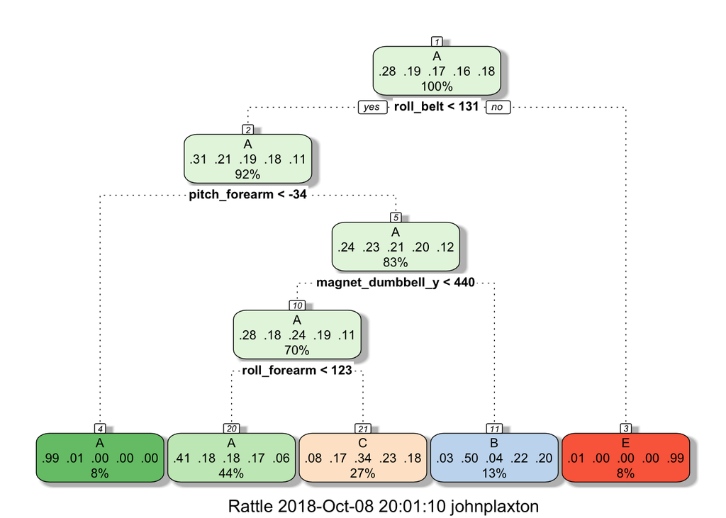

```r
fancyRpartPlot(model_CT$finalModel)
```

```r
trainpred <- predict(model_CT,newdata=testing)

confMatCT <- confusionMatrix(testing$classe,trainpred)

# display confusion matrix and model accuracy
confMatCT$table
```

```
##           Reference
## Prediction    A    B    C    D    E
##          A 1262   20  107    0    6
##          B  378  312  259    0    0
##          C  418   26  411    0    0
##          D  356  141  307    0    0
##          E  144  101  248    0  408
```

```r
confMatCT$overall[1]
```

```
## Accuracy
## 0.487969
```

Out of sample accuracy of 48.8% is achieved for the classification tree model.

### Random Forest

```r
model_RF <- train(classe~., data=training, method="rf", trControl=trControl, verbose=FALSE)
print(model_RF)
```

```
## Random Forest
##
## 14718 samples
##    52 predictor
##     5 classes: 'A', 'B', 'C', 'D', 'E'
##
## No pre-processing
## Resampling: Cross-Validated (5 fold)
## Summary of sample sizes: 11773, 11775, 11776, 11775, 11773
## Resampling results across tuning parameters:
##
##   mtry  Accuracy   Kappa
##    2    0.9920507  0.9899442
##   27    0.9911674  0.9888276
##   52    0.9850525  0.9810915
##
## Accuracy was used to select the optimal model using the largest value.
## The final value used for the model was mtry = 2.
```

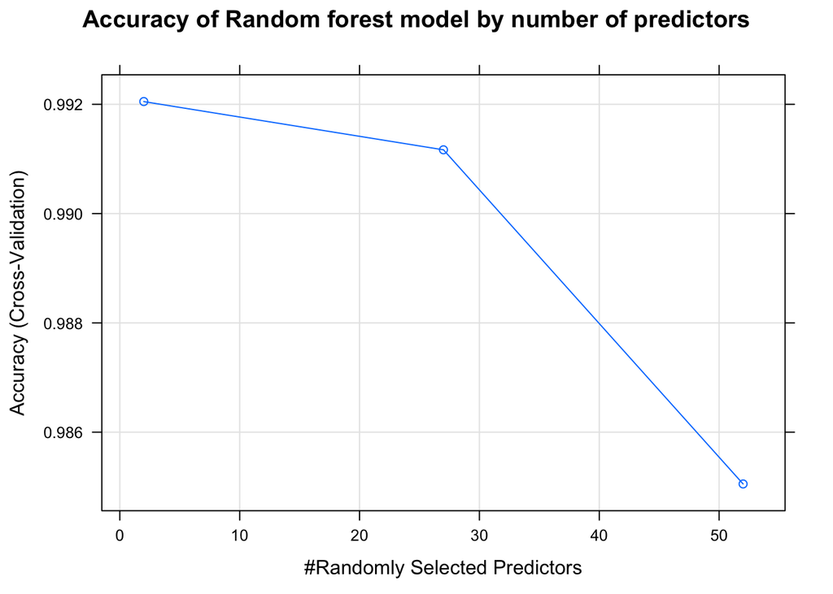

```r
plot(model_RF,main="Accuracy of Random forest model by number of predictors")
```

```r
trainpred <- predict(model_RF,newdata=testing)

confMatRF <- confusionMatrix(testing$classe,trainpred)

# display confusion matrix and model accuracy
confMatRF$table
```

```
##           Reference
## Prediction    A    B    C    D    E
##          A 1394    1    0    0    0
##          B    2  944    3    0    0
##          C    0    8  847    0    0
##          D    0    0   19  784    1
##          E    0    0    0    1  900
```

```r
confMatRF$overall[1]
```

```
## Accuracy
## 0.992863
```

With random forest, out of sample accuracy of 99.3% is achieved.

### Gradient Boosting

```r
model_GBM <- train(classe~., data=training, method="gbm", trControl=trControl, verbose=FALSE)
print(model_GBM)
```

```
## Stochastic Gradient Boosting
##
## 14718 samples
##    52 predictor
##     5 classes: 'A', 'B', 'C', 'D', 'E'
##
## No pre-processing
## Resampling: Cross-Validated (5 fold)
## Summary of sample sizes: 11775, 11773, 11775, 11775, 11774
## Resampling results across tuning parameters:
##
##   interaction.depth  n.trees  Accuracy   Kappa
##   1                   50      0.7505776  0.6836592
##   1                  100      0.8223944  0.7751950
##   1                  150      0.8526296  0.8135111
##   2                   50      0.8553477  0.8167930
##   2                  100      0.9073925  0.8827836
##   2                  150      0.9321242  0.9141188
##   3                   50      0.8950939  0.8672534
##   3                  100      0.9427918  0.9276198
##   3                  150      0.9623594  0.9523793
##
## Tuning parameter 'shrinkage' was held constant at a value of 0.1
##
## Tuning parameter 'n.minobsinnode' was held constant at a value of 10
## Accuracy was used to select the optimal model using the largest value.
## The final values used for the model were n.trees = 150,
##  interaction.depth = 3, shrinkage = 0.1 and n.minobsinnode = 10.
```

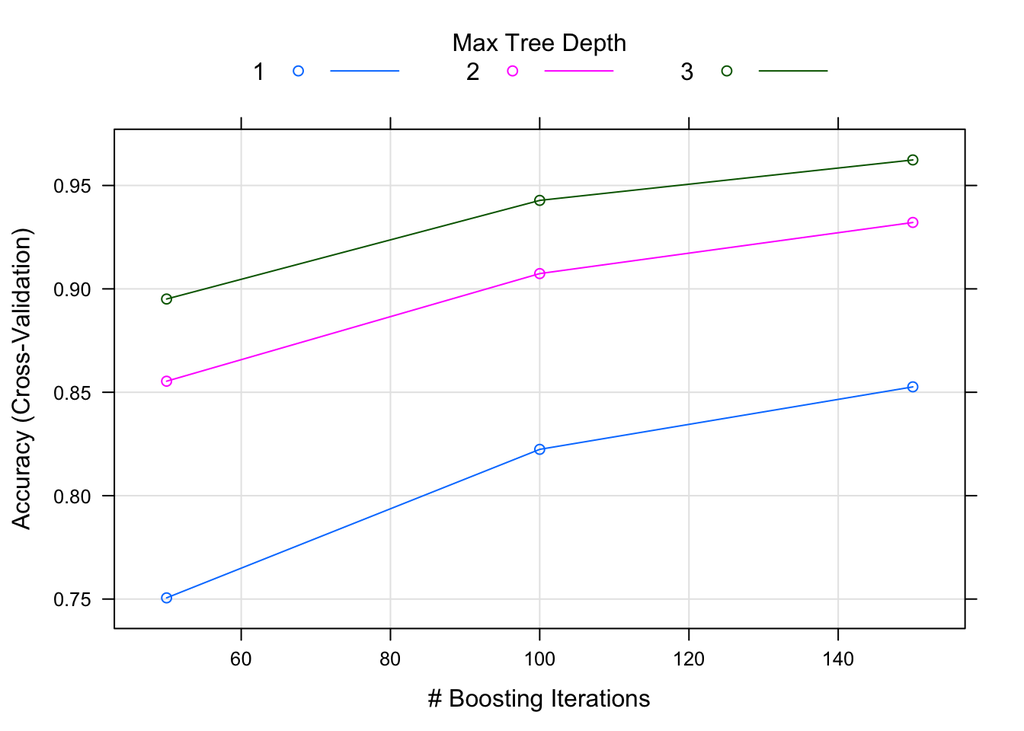

```r
plot(model_GBM)
```

```r
trainpred <- predict(model_GBM,newdata=testing)

confMatGBM <- confusionMatrix(testing$classe,trainpred)

# display confusion matrix and model accuracy
confMatGBM$table
```

```
##           Reference
## Prediction    A    B    C    D    E
##          A 1368   15    7    4    1
##          B   31  897   20    1    0
##          C    0   32  809   13    1
##          D    1    5   29  758   11
##          E    3    6    4   14  874
```

```r
confMatGBM$overall[1]
```

```
##  Accuracy
## 0.9596248
```

Out of sample accuracy of 96.0% is achieved with the Gradient Boosting method.

## Conclusion

Based upon 99.3% out of sample accuracy, Random Forest model will be used to predict the exercises of the test dataset.

```r
FinalTestPred <- predict(model_RF,newdata=TestDatasetClean)
FinalTestPred
```

```
##  [1] B A B A A E D B A A B C B A E E A B B B
## Levels: A B C D E
```

```r
#return R to single threaded processing
stopCluster(cluster)
registerDoSEQ()
```

## Appendix

Summary of the TrainDataset:

```r
str(TrainDataset)
```

```
## 'data.frame':    19622 obs. of  160 variables:
##  $ X                       : int  1 2 3 4 5 6 7 8 9 10 ...
##  $ user_name               : Factor w/ 6 levels "adelmo","carlitos",..: 2 2 2 2 2 2 2 2 2 2 ...
##  $ raw_timestamp_part_1    : int  1323084231 1323084231 1323084231 1323084232 1323084232 1323084232 1323084232 1323084232 1323084232 1323084232 ...
##  $ raw_timestamp_part_2    : int  788290 808298 820366 120339 196328 304277 368296 440390 484323 484434 ...
##  $ cvtd_timestamp          : Factor w/ 20 levels "02/12/2011 13:32",..: 9 9 9 9 9 9 9 9 9 9 ...
##  $ new_window              : Factor w/ 2 levels "no","yes": 1 1 1 1 1 1 1 1 1 1 ...
##  $ num_window              : int  11 11 11 12 12 12 12 12 12 12 ...
##  $ roll_belt               : num  1.41 1.41 1.42 1.48 1.48 1.45 1.42 1.42 1.43 1.45 ...
##  $ pitch_belt              : num  8.07 8.07 8.07 8.05 8.07 8.06 8.09 8.13 8.16 8.17 ...
##  $ yaw_belt                : num  -94.4 -94.4 -94.4 -94.4 -94.4 -94.4 -94.4 -94.4 -94.4 -94.4 ...
##  $ total_accel_belt        : int  3 3 3 3 3 3 3 3 3 3 ...
##  $ kurtosis_roll_belt      : Factor w/ 397 levels "","-0.016850",..: 1 1 1 1 1 1 1 1 1 1 ...
##  $ kurtosis_picth_belt     : Factor w/ 317 levels "","-0.021887",..: 1 1 1 1 1 1 1 1 1 1 ...
##  $ kurtosis_yaw_belt       : Factor w/ 2 levels "","#DIV/0!": 1 1 1 1 1 1 1 1 1 1 ...
```

[output cut: 86 more lines]